# Covid-19,Analysis

Gurmeet Singh

13/04/2020

# Introduction

The aim of this kernel is understand COVID-19 India better, by implementing/viewing the data graphically

### The Story of COVID-19 in India

The COVID-19 pandemic is the defining global health crisis of our time and the greatest global humanitarian challenge the world has faced since World War II. The virus has spread widely, and the number of cases is rising daily as governments work to slow its spread. India has moved quickly, implementing a proactive, nationwide, 21-day lockdown, with the goal of flattening the curve and using the time to plan and resource responses adequately.

## Load libraries

We load a range of libraries for general data wrangling and visualization.

```r
library(readr)
library(ggplot2)
library(dplyr)
```

### Reading the dataset

```r
Details <- read_csv("https://raw.githubusercontent.com/gurmeetsingh0111/Data-Analysis-project/master/IndividualDetails.csv")
```

```
## `curl` package not installed, falling back to using `url()`
```

### Cleaning the data by removing the `NA` values and some coloumns which are not that useful

```r
data = Details[,c(1,3,4,5,8,9,10,11)]

d_subset = na.omit(data)
write.csv(d_subset, file="file.csv")

d_subset<-as.data.frame(d_subset)
```

**Note that after removing all the NA values the data remained is 12.35% of the original data.**

setting the date format

```r
d_subset$diagnosed_date<-as.Date(d_subset$diagnosed_date,'%d/%m/%Y')
```

## Data Visualization

### Age Group Analysis

```r
age<-read_csv("https://raw.githubusercontent.com/gurmeetsingh0111/Data-Analysis-project/master/AgeGroupDetails.csv")
```

```
## `curl` package not installed, falling back to using `url()`
```

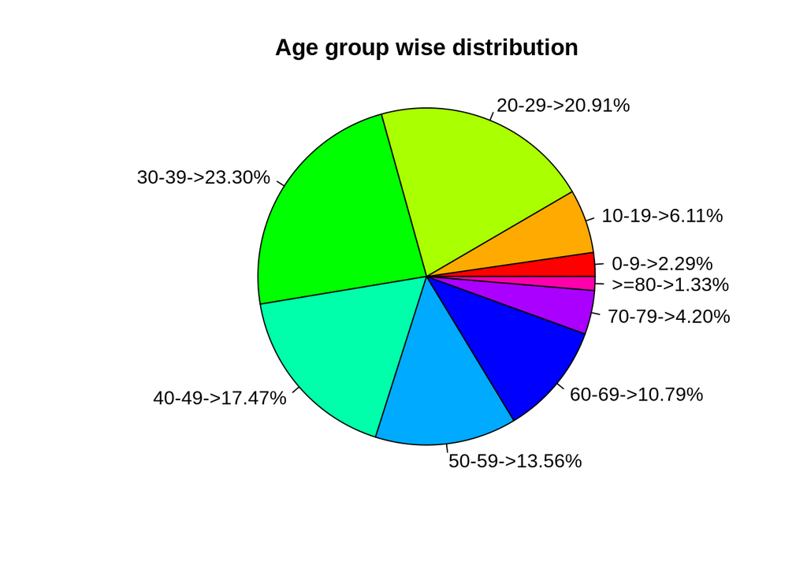

```r
age<-as.data.frame(age)
lbls<-c("0-9","10-19","20-29","30-39","40-49","50-59","60-69","70-79",">=80")
pct<-c(age$Percentage)
lbls<-paste(lbls,pct,sep = "->")
pie(age$TotalCases,labels=lbls,col=rainbow(length(age$AgeGroup)),radius=1,border=1,main="Age group wise distribution")
```

We could see that the **age group <50 is the most affected** which is against the trend which says elderly people are more at risk of being affected. Only 16% of people >60 are affected. May be because young people meet and travel much more than older people so they were under the threat of community transmission…!

### Percentage of gender

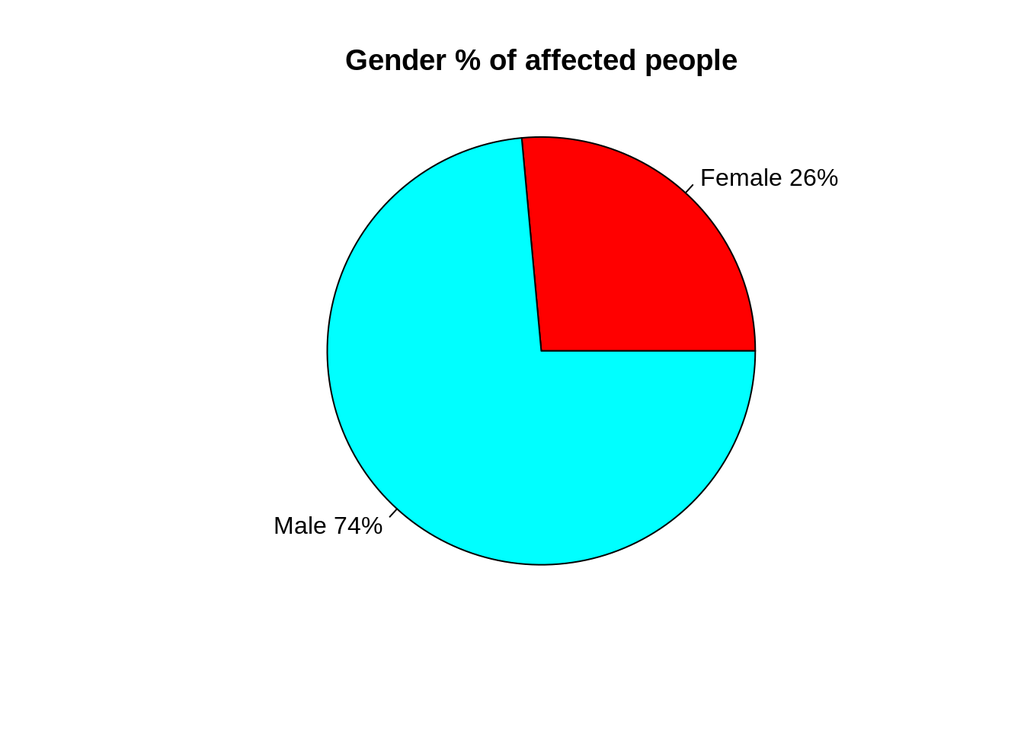

```r
fm<-table(d_subset$gender)
totalfemale<-fm[1]
totalmale<-fm[2]

slices <- c(fm[1],fm[2])
pct <- round(slices/sum(slices)*100)
lbls <- c("Female", "Male")
lbls <- paste(lbls, pct) # add percents to labels
lbls <- paste(lbls,"%",sep="") # ad % to labels
pie(slices,labels = lbls, col=rainbow(length(lbls)),radius=1,border=1,
    main="Gender % of affected people")
```

This Tells that Female patients are very less as compared to the male patients. Men were the most affected accounting to 74%

### Current status of patients

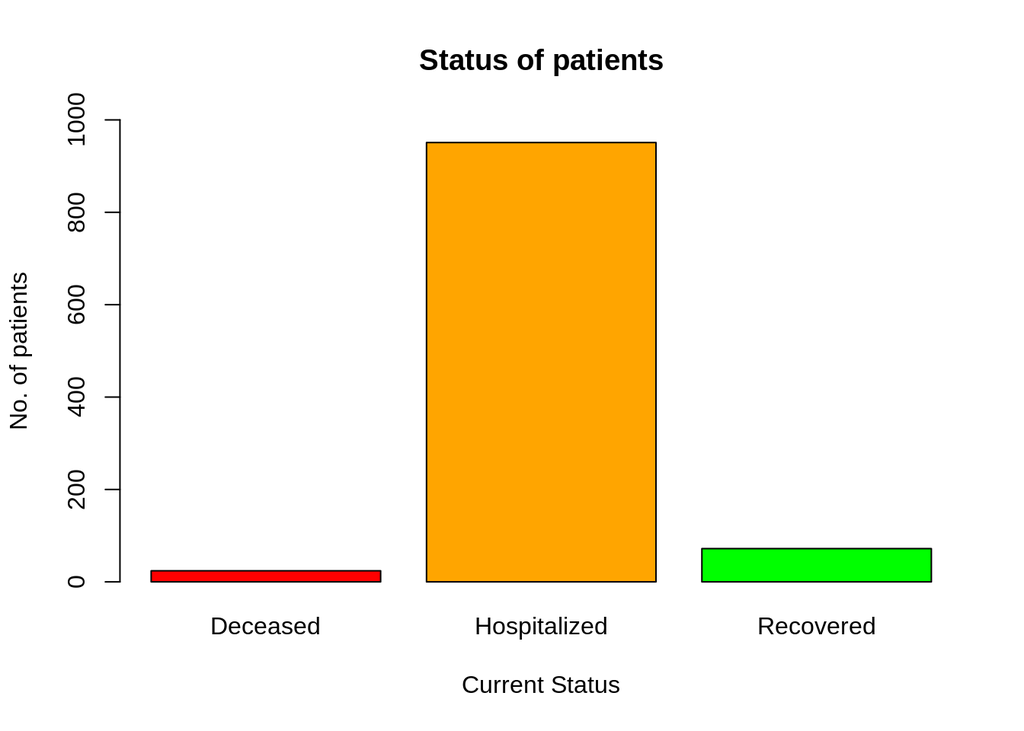

```r
status<-table(d_subset$current_status)
barplot(status,col=c("red","orange","green"),xlab = "Current Status",ylim=c(0,1000),ylab = "No. of patients",main = "Status of patients")
```

Most of them are still held in quarantine

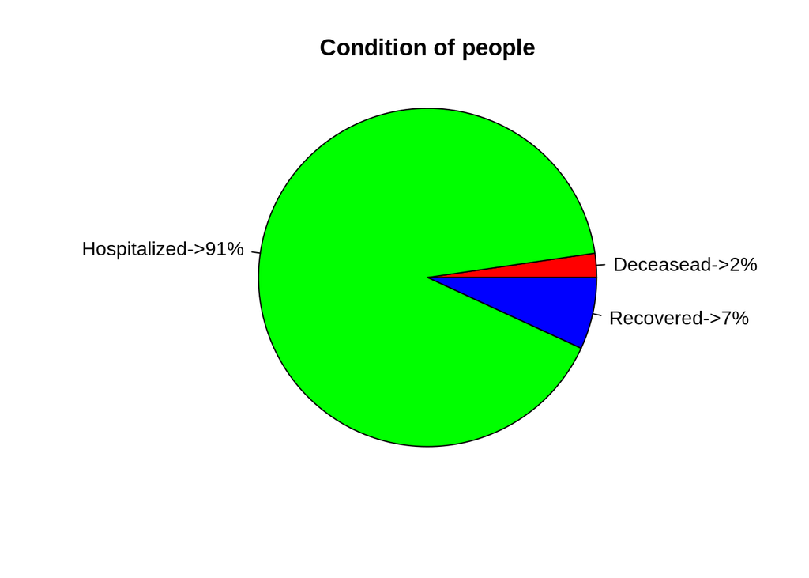

```r
spect<-round(status/sum(status)*100)
lbls<-c("Deceasead","Hospitalized","Recovered")
lbls<-paste(lbls,spect,sep = "->")
lbls<-paste(lbls,"%",sep = "")
pie(status,labels=lbls,col=rainbow(3),radius=1,border=1,main="Condition of people")
```

Only 2% of the total affected people died

### Recovery of patients gender wise

```r
recovered1<-filter(d_subset,d_subset$gender=='M' & d_subset$current_status=="Recovered")
recovered2<-filter(d_subset,d_subset$gender=='F' & d_subset$current_status=="Recovered")
rc1<-as.integer(count(recovered1))
rc2<-as.integer(count(recovered2))
deceased1<-filter(d_subset,d_subset$gender=='M' & d_subset$current_status=="Deceased")
deceased2<-filter(d_subset,d_subset$gender=='F' & d_subset$current_status=="Deceased")
dc1<-as.integer(count(deceased1))
dc2<-as.integer(count(deceased2))

c1<-c(rc1,rc2)
c1
```

```
## [1] 49 23
```

```r
c2<-c(dc1,dc2)
c2
```

```
## [1] 17  7
```

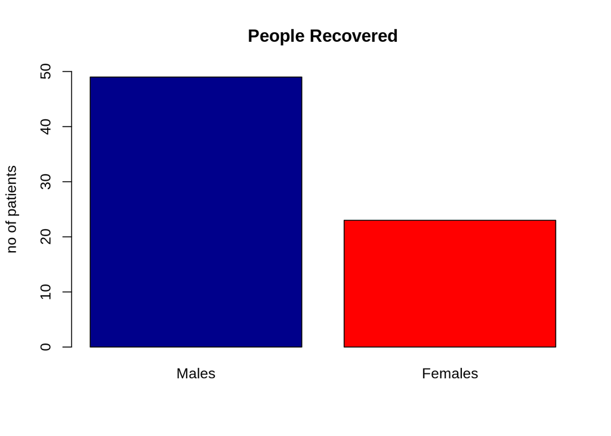

```r
rd<-c("Males","Females")
barplot(c1, main="People Recovered",names.arg = rd,
        ylab="no of patients",ylim =c(0,50), col=c("darkblue","red"),
         )
```

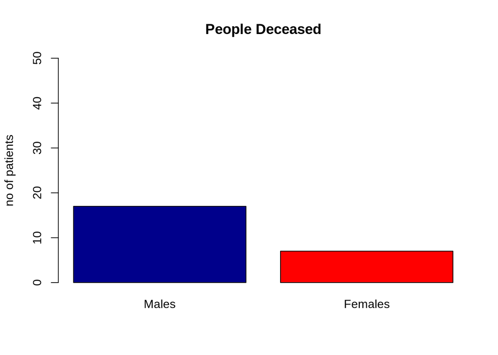

```r
barplot(c2, main="People Deceased",names.arg = rd,
        ylab="no of patients",ylim =c(0,50), col=c("darkblue","red"),
)
```

### Recovery,Deceased ration of Males v/s Females

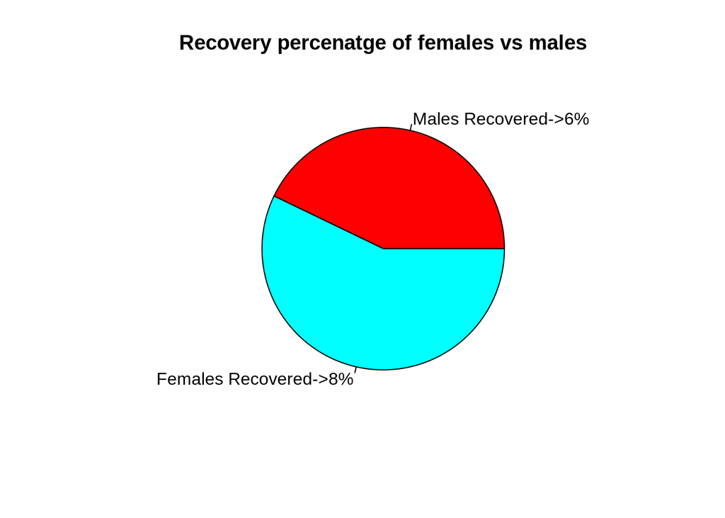

```r
pfr<-round((rc2/totalfemale)*100)
pmr<-round((rc1/totalmale)*100)
pct <- c(pmr,pfr)
lbls <- c("Males Recovered", "Females Recovered")
lbls <- paste(lbls, pct,sep="->") # add percents to labels
lbls <- paste(lbls,"%",sep="") # ad % to labels
pie(pct,labels = lbls, col=rainbow(length(lbls)),
    main="Recovery percenatge of females vs males")
```

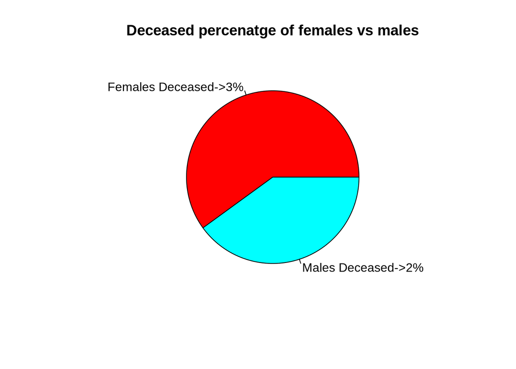

```r
pfd<-round((dc2/totalfemale)*100)
pmd<-round((dc1/totalmale)*100)
pct <- c(pfd,pmd)
lbls <- c("Females Deceased", "Males Deceased")
lbls <- paste(lbls, pct,sep="->") # add percents to labels
lbls <- paste(lbls,"%",sep="") # ad % to labels
pie(pct,labels = lbls, col=rainbow(length(lbls)),
    main="Deceased percenatge of females vs males")
```

### Quarantine gender ratio

```r
q1<-filter(d_subset,d_subset$gender=='M' & d_subset$current_status=="Hospitalized")
q2<-filter(d_subset,d_subset$gender=='F' & d_subset$current_status=="Hospitalized")
qc1<-as.integer(count(q1))
qc1
```

```
## [1] 704
```

```r
qc2<-as.integer(count(q2))
qc2
```

```
## [1] 247
```

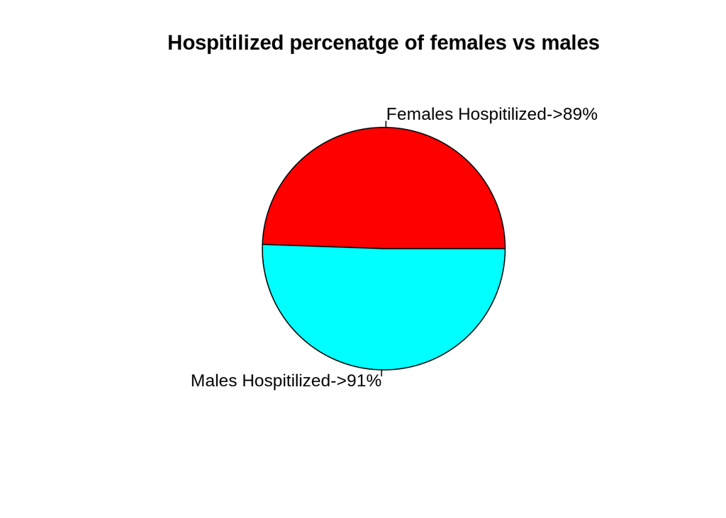

```r
q<-c(qc2,qc1)
pfq<-round((qc2/totalfemale)*100)
pmq<-round((qc1/totalmale)*100)
pct <- c(pfq,pmq)
lbls <- c("Females Hospitilized", "Males Hospitilized")
lbls <- paste(lbls, pct,sep="->") # add percents to labels
lbls <- paste(lbls,"%",sep="") # ad % to labels
pie(pct,labels = lbls, col=rainbow(length(lbls)),
    main="Hospitilized percenatge of females vs males")
```

Both 90% of Males and Females are still in quarantine

### No. Of Cases per day

```r
ad<- d_subset %>%
  group_by(diagnosed_date)%>%
  summarise(n_distinct(id))
ad
```

```
## # A tibble: 42 x 2
##    diagnosed_date `n_distinct(id)`
##    <date>                    <int>
##  1 2020-01-30                    1
##  2 2020-03-02                    2
##  3 2020-03-03                    1
##  4 2020-03-04                    3
##  5 2020-03-05                    2
##  6 2020-03-07                    3
##  7 2020-03-08                    5
##  8 2020-03-09                    4
##  9 2020-03-10                    6
## 10 2020-03-11                    4
## # … with 32 more rows
```

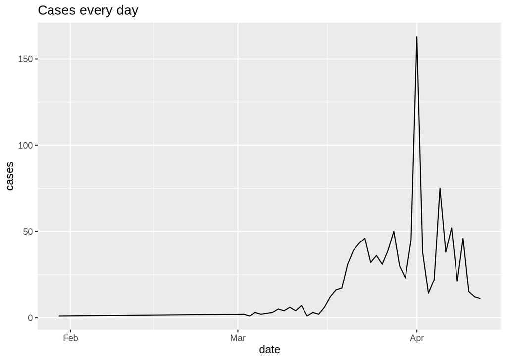

```r
colnames(ad)<-c("date","cases")

ad$date<-as.Date(ad$date,'%d/%m/%Y')
require(ggplot2)
ggplot(data = ad,aes(date,cases))+geom_line()+labs(title = "Cases every day")
```

### Max cases on a single day

```r
m=max(ad[,2])
r=0
for(i in 1:nrow(ad))
  if(ad[i,2]!=m)
    {r=r+1}else{break}
print("Maximum cases on a single day were on ")
```

```
## [1] "Maximum cases on a single day were on "
```

```r
print(ad[r+1,1])
```

```
## # A tibble: 1 x 1
##   date
##   <date>
## 1 2020-04-01
```

### Statewise Insights

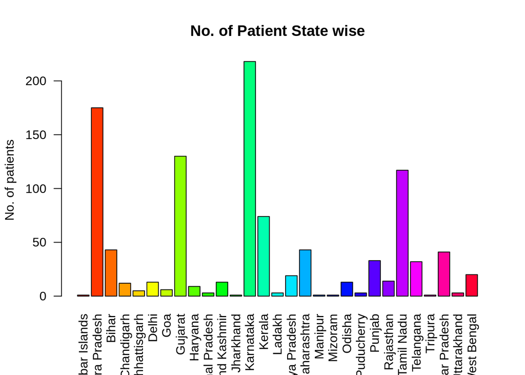

```r
State<- d_subset %>%
  group_by(detected_state)%>%
  summarise(n_distinct(id))
colnames(State)<-c("state","cases")

barplot(State$cases,col=rainbow(29),names.arg = State$state,las=2,ylab = "No. of patients",main = "No. of Patient State wise")
```

This tells us which state got the most no. Of cases currently

### Outsiders affected by the virus in Inida

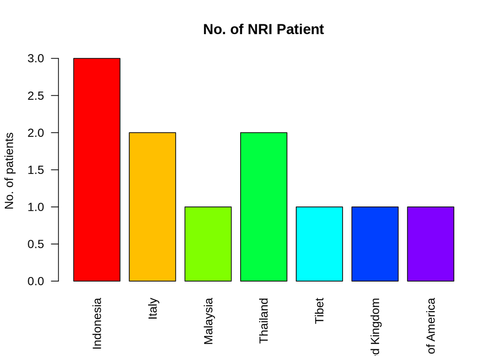

```r
nation=d_subset%>%
  group_by(nationality)%>%
  summarise(n_distinct(id))
colnames(nation)<-c("nationality","cases")
row_to_keep = c(FALSE,FALSE, TRUE, TRUE, TRUE, TRUE, TRUE,TRUE, TRUE)
nation = nation[row_to_keep,]
barplot(nation$cases,col=rainbow(8),names.arg = nation$nationality,las=2,ylab = "No. of patients",main = "No. of NRI Patient")
```

We can say that these people carried virus from thier respective countries or from anyother county to India while travlling

### Fatality Rate

```r
tdeaths=0
fdeaths=0
mdeaths=0
for(i in 1:nrow(d_subset)){
  if(d_subset[i,7]=="Deceased")
    tdeaths=tdeaths+1
}

for(i in 1:nrow(d_subset)){
  if(d_subset[i,7]=="Deceased"&&d_subset[i,4]=="F")
    fdeaths=fdeaths+1

}
for(i in 1:nrow(d_subset)){
  if(d_subset[i,7]=="Deceased"&&d_subset[i,4]=="M")
    mdeaths=mdeaths+1
}
mdeaths
```

```
## [1] 17
```

```r
fdeaths
```

```
## [1] 7
```

```r
tdeaths
```

```
## [1] 24
```

```r
#fatality rate
fratefemale=fdeaths/totalfemale*100
fratefemale
```

```
##        F
## 2.527076
```

```r
fratemale=mdeaths/totalmale*100
fratemale
```

```
##        M
## 2.207792
```

```r
frate=tdeaths/1047*100
frate
```

```
## [1] 2.292264
```

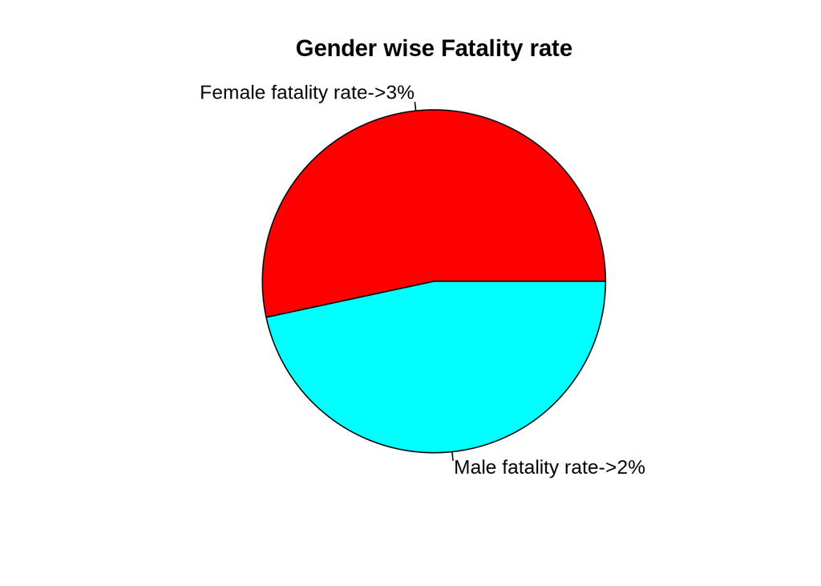

```r
rate<-c(fratefemale,fratemale)
lbls<-c("Female fatality rate","Male fatality rate")
pct<-round(rate)
lbls<-paste(lbls,pct,sep = "->")
lbls<-paste(lbls,"%",sep = "")
pie(rate,labels=lbls,col=rainbow(2),radius=1,border=1,main="Gender wise Fatality rate")
```

Difference in Fatality rate in both the genders in not that much also considering the no. of deaths were very low